# (Data Analysis: Loan Data from Prosper)

## by (Arvind Sharma)

## Investigation Overview

This presentation explores data on America's first peer-to-peer, or marketplace lending platform Prosper. The aim of this exploration is to try and understand how peer-to-peer, or marketplace lending works for Prosper. There are two questions that are at the heart of this which are as mentioned below:

- What risk factors does Prosper consider before granting loans?
- What are the trends in returns for the granted loans by Prosper?

## Dataset Overview

This is the result of Exploratory Data Analysis (EDA) on a data set from Prosper, which is America’s first peer-to-peer, or marketplace, lending platform, with over $9 billion in funded loans. This data set contains 113,937 loans with 81 variables on each loan, including loan amount, borrower rate (or interest rate), current loan status, borrower income, borrower employment status, borrower credit history, and the latest payment information.

This [data dictionary](https://docs.google.com/spreadsheets/d/1gDyi_L4UvIrLTEC6Wri5nbaMmkGmLQBk-Yx3z0XDEtI/edit#gid=0) explains the variables in the data set.

## (Visualization 1)

There is a negative linear relationship between the features 'ProsperRating (numeric)' to evaluate risk and 'BorrowerRate'. It shows that loans with high borrower rate are most common with smaller prosper rating (i.e. higher risk values). This can also be validated from the right subplot where the median values starting from 'PropserRating (numeric)' 1 to 7 emulate a negative linear relationship.

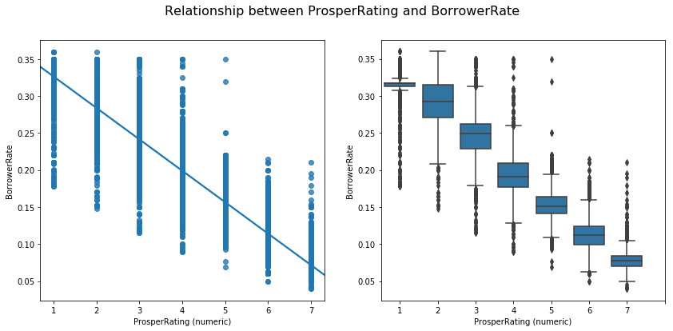

```python
default_color = sb.color_palette()[0]
plt.figure(figsize=(14, 6))

plt.subplot(1, 2, 1)
sb.regplot(data=df, x='ProsperRating (numeric)', y='BorrowerRate')

plt.subplot(1, 2, 2)
sb.boxplot(data=df, x='ProsperRating (numeric)', y='BorrowerRate', color=default_color)
plt.xticks(np.arange(0, 8, 1), ('1', '2', '3', '4', '5', '6', '7'))
plt.suptitle('Relationship between ProsperRating and BorrowerRate', fontsize=16);
```

## (Visualization 2)

Higher monthly income tend to be identified with higher prosper score (better risk profile), even though there are a few outliers where higher monthly incomes are categorized with low prosper score (high risk profile).

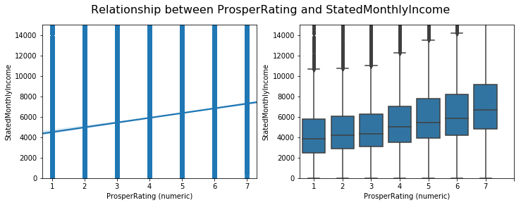

```python
plt.figure(figsize=(12, 4))

plt.subplot(1, 2, 1)
sb.regplot(data=df, x='ProsperRating (numeric)', y='StatedMonthlyIncome')
plt.ylim((0, 15000));

plt.subplot(1, 2, 2)
sb.boxplot(data=df, x='ProsperRating (numeric)', y='StatedMonthlyIncome', color=default_color)
plt.ylim((0, 15000))
plt.xticks(np.arange(0, 8, 1), ('1', '2', '3', '4', '5', '6', '7'))
plt.suptitle('Relationship between ProsperRating and StatedMonthlyIncome', fontsize=16);
```

## (Visualization 3)

There is a negative linear relationship between the features 'AvailableBankcardCredit' and the 'BorrowerRate' such that higher values of 'AvailableBankcardCredit' lowers the 'BorrowerRate' values.

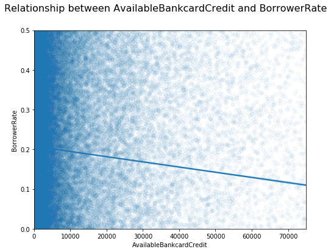

```python
plt.figure(figsize = [8, 6])
sb.regplot(data=df, x='AvailableBankcardCredit', y='BorrowerRate', \
           x_jitter = 0.5, y_jitter = 0.5, scatter_kws = {'alpha' : 1/30})
plt.xlim((0, 75000))
plt.ylim(0, 0.5)
plt.suptitle('Relationship between AvailableBankcardCredit and BorrowerRate', fontsize=16);
```

## (Visualization 4)

As the 'ProsperRating (numeric)' move from lower to higher values of 1 to 7, 'DebtToIncomeRatio' as well as 'BorrowerRate' decreases which signifies that higher ’DebtToIncomeRatio' and 'BorrwerRate' are associated with lower 'ProsperRating (numeric)'. In other words, lower 'DebtToIncomeRatio' and 'BorrowerRate' are key indicators for a higher Prosper rating i.e. 'ProsperRating (numeric)’.

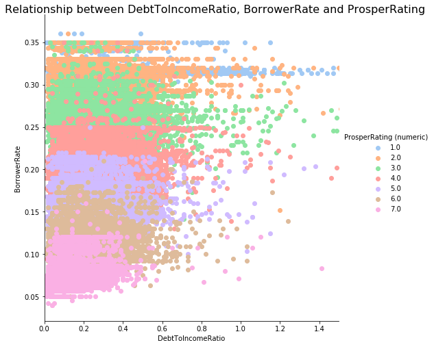

```python
g = sb.FacetGrid(data=df, hue='ProsperRating (numeric)', size=7, palette='pastel')
g.map(plt.scatter, 'DebtToIncomeRatio', 'BorrowerRate')
plt.xlim((0, 1.5))
g.add_legend()
plt.suptitle('Relationship between DebtToIncomeRatio, BorrowerRate and ProsperRating', fontsize=16, y=1);
```

## (Visualization 5)

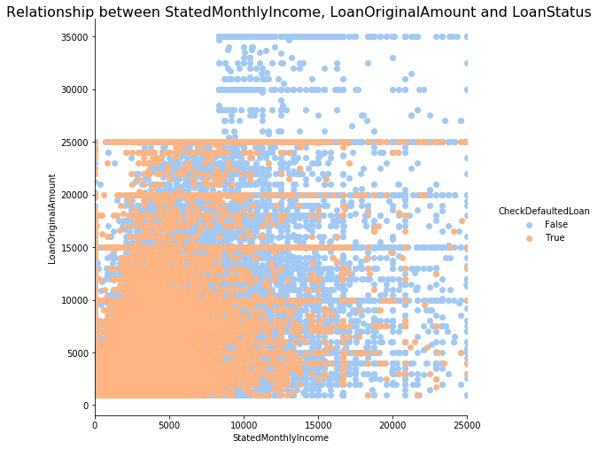

```python
# Create new feature 'CheckDefaultedLoan'
# 'CheckDefaultedLoan' has value 'True' for defaulted/chargedoff loans and value 'False' for completed loans
df['CheckDefaultedLoan'] = (df['LoanStatus'] == 'Defaulted') | (df['LoanStatus'] == 'Chargedoff')

g = sb.FacetGrid(data=df, hue='CheckDefaultedLoan', size=7, palette='pastel')
g.map(plt.scatter, 'StatedMonthlyIncome', 'LoanOriginalAmount')
plt.xlim((0, 25000))
g.add_legend()
plt.suptitle('Relationship between StatedMonthlyIncome, LoanOriginalAmount and LoanStatus', fontsize=16, y=1);
```

## (Visualization 6)

As the borrower moves from lower to higher income ranges, Prosper decreases the 'BorrowerRate' making it an important player in the lending market.

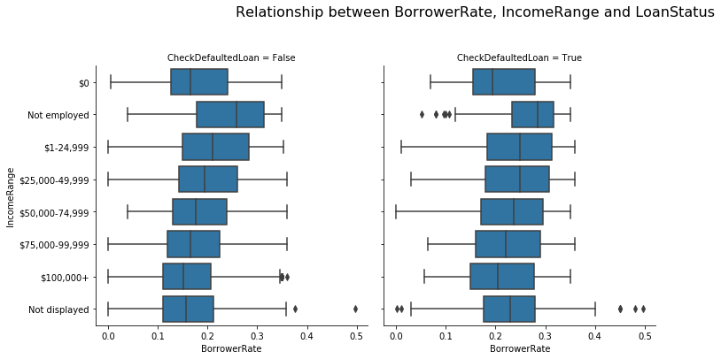

```python
income_range_order = ['$0', 'Not employed', '$1-24,999', '$25,000-49,999', '$50,000-74,999', '$75,000-99,999', '$100,000+', 'Not displayed']
ordered_cat = pd.api.types.CategoricalDtype(ordered=True, categories=income_range_order)
df['IncomeRange'] = df['IncomeRange'].astype(ordered_cat)

g = sb.FacetGrid(data=df, col='CheckDefaultedLoan', size=5, col_wrap=3)
g.map(sb.boxplot, 'BorrowerRate', 'IncomeRange')
plt.suptitle('Relationship between BorrowerRate, IncomeRange and LoanStatus', fontsize=16, y=1.12);
```

## (Visualization 7)

Majority of Prosper loans fall under 36 to 60 months term owing to lower feature value of 'MonthlyLoanPayment' when compared to the 12 month term.

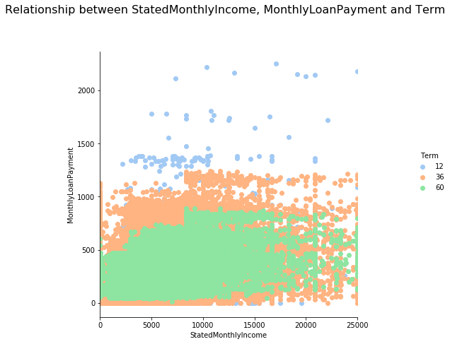

```python
g = sb.FacetGrid(data=df, hue='Term', size=6, palette='pastel')
g.map(plt.scatter, 'StatedMonthlyIncome', 'MonthlyLoanPayment')
plt.xlim((0, 25000))
g.add_legend()
plt.suptitle('Relationship between StatedMonthlyIncome, MonthlyLoanPayment and Term', fontsize=16, y=1.12);
```

## (Visualization 8)

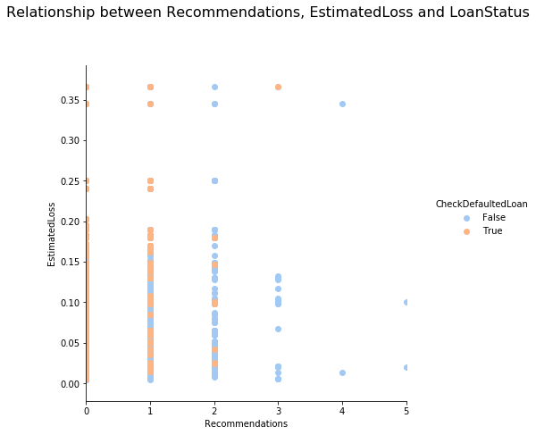

```python
g = sb.FacetGrid(data=df, hue='CheckDefaultedLoan', size=6, palette='pastel')
g.map(plt.scatter, 'Recommendations', 'EstimatedLoss')
plt.xlim((0, 5))
g.add_legend()
plt.suptitle('Relationship between Recommendations, EstimatedLoss and LoanStatus', fontsize=16, y=1.12);
```

## (Visualization 9)

As the prosper rating increases the estimated loss shows a marked decrease indicating that Prosper has a strong rating mechanism to avoid defaulted or charged off loans which might result in loss. Prosper's success in the peer-to-peer, marketplace lending can be attributed to its strong and robust rating system.

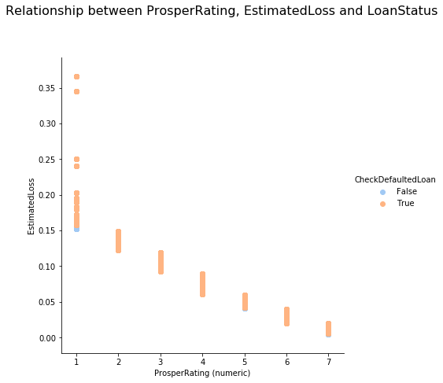

```python
g = sb.FacetGrid(data=df, hue='CheckDefaultedLoan', size=6, palette='pastel')
g.map(plt.scatter, 'ProsperRating (numeric)', 'EstimatedLoss')
g.add_legend()
plt.suptitle('Relationship between ProsperRating, EstimatedLoss and LoanStatus', fontsize=16, y=1.12);
```